# 広告効果を推定しつつ回帰を回したい

Y.Nakahashi

2018-03-15

### 背景

しつこいようですが、*Marketing Mix Modeling*（*MMM*）の話題です。

先日、[こんな面白い論文](https://static.googleusercontent.com/media/research.google.com/ja//pubs/archive/45999.pdf)を見つけました。 GoogleのResearcherによるMMMの論文（彼らはMedia Mix Modelingと呼んでいます）なのですが、**ヒルの式**を用いて広告のShape効果（Carveture効果）を推定するということをやっています。ここでShape効果・carveture効果とは、メディアの露出量に対する目的変数の反応を示す曲線を指すようで、ヒルの式とは：

$$H(x; K, S) = \frac{1}{1 + (\frac{x}{K})^{-S}}$$
であり、$K > 0$や$S > 0$となるパラメータによってLogやSigmoidの形状を表現することができるようです。

続いて、パラメータとなる`k`と`s`をそれぞれ以下のように設定した場合をプロットしてみましょう。なおこの数値は論文から拝借しています。

```r
x <- seq(0, 1, by = 0.05)
plot(x, hill_transformation(x, 0.4, 4),
     type = "l", col = 2, xlim = c(0, 1), ylim = c(0, 1),
     ylab = "Hill Transformed Value")
par(new = T)
```

```r
plot(x, hill_transformation(x, 0.4, 1),
     type = "l", col = 3, xlim = c(0, 1), ylim = c(0, 1), axes = F,
     ylab = "")
par(new = T)
```

```r
plot(x, hill_transformation(x, 0.8, 4),
     type = "l", col = 4, xlim = c(0, 1), ylim = c(0, 1), axes = F,
     ylab = "")
par(new = T)
```

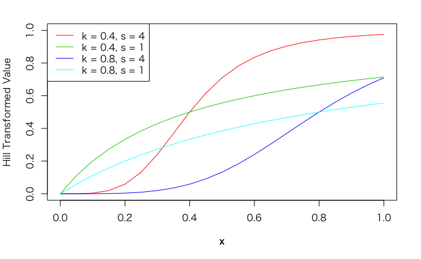

```r
plot(x, hill_transformation(x, 0.8, 1),
     type = "l", col = 5, xlim = c(0, 1), ylim = c(0, 1), axes = F,
     ylab = "")
legend("topleft", legend = c("k = 0.4, s = 4", "k = 0.4, s = 1",
                             "k = 0.8, s = 4", "k = 0.8, s = 1"),
       col = c(2:5), lty = rep(1, 4))
```

このように、パラメータを変更することで元の値を柔軟に変換することが可能です。これまで私が書いてきた記事では、いずれも広告効果（回帰係数）そのものを推定する方法にばかり注目しており、説明変数の“効き方”については触れてきませんでした。これではちょっと検討が足りないと言われても仕方ありません。

というわけで本エントリーでは、ヒルの式により変換したXを用いてシミュレーションデータを発生させ、元のXから変数変換のためのパラメータを推定できるかを検証したいと思います。なお元論文ではAd-Stock効果としてGeometric Ad-Stock：

$$GA(x_{t}; \alpha, L) = \frac{\sum_{l = 0}^{L}x_{t-l}\alpha^{l}}{\sum_{l = 0}^{L}\alpha^{l}}$$

を用いていますが、今回の検証ではAd-Stock効果をみておらず、説明変数の生の値を変換しています[^1]。

#### ライブラリの読み込み

今回の分析でも`{rstan}`を使用します。

#### シミュレーションデータの生成

分析用のデータ生成ですが、まず説明変数`X1`を*runif*により作成します。次に与えたパラメータからヒルの式を用いて変換し、目的変数`y`を作成します。

`X1`について、

- 推定したい広告効果 ⇒ `0.8`
- ヒルの式の`k`および`s` ⇒ `0.4`および`4`

と指定しており、これらのパラメータを元の`X_01`から推定することが狙いです。ちなみに今回のパラメータでは`X_01`と`変換後のX_01`は以下のようになります：

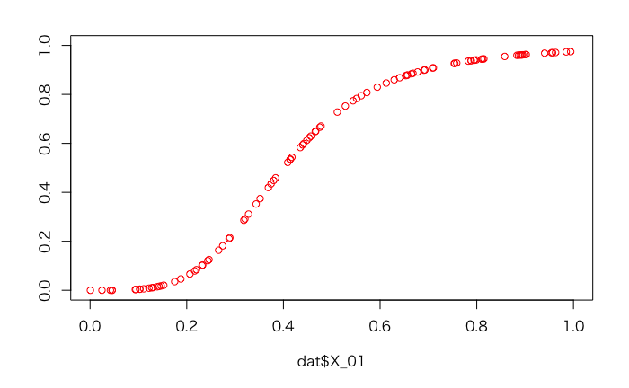

#### optimによるフィッティング

手始めに*optim*を使ってフィッティングしてみましょう。これまでの記事でも度々*optim*を使ってきましたが、なかなか精度良く推定することが可能です。ただしAICを計算するのが面倒なのでここでは`beta`を直接推定しないことにして、*lm*を使います。よって推定対象は`k_01`と`s_01`の２つだけです。

```r
### 適当な数値を入れてみる
return_AIC(rep(0.5, 2), dat)
```

```
[1] 60.47417
```

ちゃんと動くようなのでフィッティングしてみましょう。

パラメータを確認してみると：

```r
print(cbind(true_par, optim_par), digits = 2)
```

```
              true_par optim_par
X_01_conv_opt      0.8       1.1
                   0.4       0.5
                   4.0       1.9
```

うーん、`s`がちょっと外れているようですね。推定された値でのプロットを見てみましょう。

```r
plot(dat$X_01, hill_transformation(dat$X_01, 0.4, 4),
     col = 2, xlim = c(0, 1), ylim = c(0, 1),
     ylab = "Hill Transformed Value")
par(new = T)
```

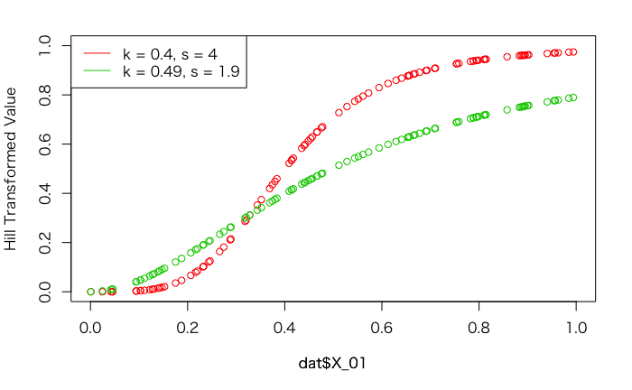

```r
plot(dat$X_01, hill_transformation(dat$X_01, res_optim$par[1], res_optim$par[2]),
     col = 3, xlim = c(0, 1), ylim = c(0, 1), axes = F,
     ylab = "")
legend("topleft", legend = c("k = 0.4, s = 4", "k = 0.49, s = 1.9"),
       col = c(2:3), lty = rep(1, 2))
```

ちょっとカーブのメリハリがなく、全体として直線的になってしまっています。これが今回のサンプルで偶々発生したものなのか、それとも`s`の推定に何らかの偏りがあるのか確かめて見ましょう。同様の試行を1,000回繰り返してみます。

```r
for (i in 1:n) {
   res_optim_all[i, ] <- tryCatch(try_s(pars), error = function(e) return(rep(0, 3)))
}
```

*tryCatch*を使って無理やりループを回しましたが、やはり推定が不安定なようで全体の4割ちょっとしか収束していません。その収束した解のバラツキを見てみても以下のようにかなり広がってしまっています。

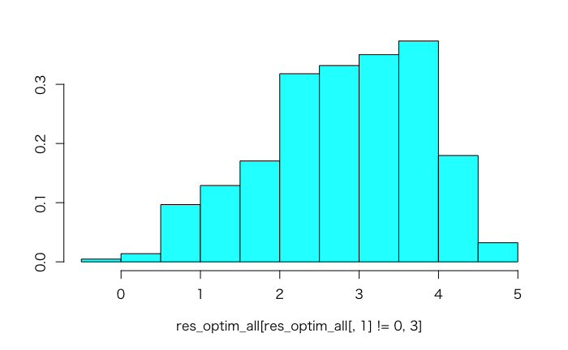

#### Stanによるフィッティング

またStanのスクリプトは以下のようになります。今回は特別な指定はしていませんが、`X_01_conv`を作成するために*transformed_parameters*ブロックを置いています。

```stan
data {
   int N;
   vector[N] Y;
   vector[N] X_01;
}

parameters {
   real mu;
   real beta_01;
   real<lower=0, upper=1> shape_k_01;
   real<lower=0, upper=5> shape_s_01;
   real<lower=0> var_error;
}

transformed parameters {
   vector[N] X_01_conv;
   for(k in 1:N) {
      X_01_conv[k] = 1 / (1 + (X_01[k] / shape_k_01)^-shape_s_01);
   }
}

model {
   // Sampling
   for(i in 1:N) {
      Y[i] ~ normal(mu + beta_01 * X_01_conv[i], var_error);
   }
}
```

上記のモデルを用いて、フィッティングしてみましょう。

```r
fit_01 <- stan(file = '/Users/nakahashi/Desktop/Git/MarketingMixModeling/Hill_Transformation.stan',
               data = dat_Stan,
               iter = 10000,
               chains = 4,
               seed = 123)
```

[output not shown]

[output cut: 44 more lines]

[output not shown]

#### 結果の確認

フィッティングが終わったので、結果を見てみましょう。`fit_01`からサンプルを抽出して加工します。

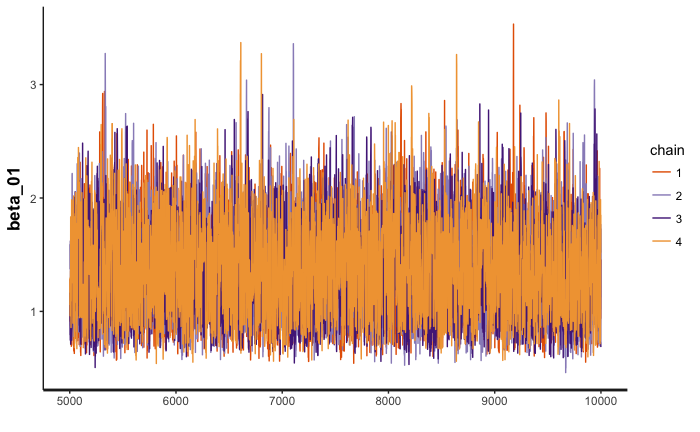

ひとまず回帰係数の推定結果を見てみましょう。実際の値と推定値を並べてみます。

```r
sprintf("True = 0.8, Stan_Est = %.3f, Optim_Est = %.3f", beta_par$mean, optim_par[1])
```

```
[1] "True = 0.8, Stan_Est = 1.369, Optim_Est = 1.111"
```

あらら、*optim*の結果よりも外れてしまいました。Shape効果の方はどうでしょうか。

```r
ests %>%
   data.frame() %>%
   select(mean) %>%
   mutate(Par = rownames(ests),
          Type = "Stan") %>%
   filter(Par %in% shape_rows) %>%
   bind_rows(data.frame(
      mean = c(0.4, 4, optim_par[-1]),
      Par = rep(c("shape_k_01", "shape_s_01"), 2),
      Type = c(rep("True", 2), rep("Optim", 2))
   )) %>%
   spread(Type, mean) %>%
   select(Par, True, Stan, Optim)
```

```
binding character and factor vector, coercing into character vectorbinding character and factor vector, coercing into character vector
```

|  | Par | True | Stan | Optim |
| --- | --- | --- | --- | --- |
| 1 | shape_k_01 | 0.4 | 0.6308075 | 0.4965623 |
| 2 | shape_s_01 | 4.0 | 1.8736434 | 1.9041772 |

こちらも*optim*の方がまだ設定値に近いようですね。

#### 終わりに

というわけで、今回はあまりパッとしない結果となってしまいました。本当なら良い推定値が得られるようになるまで頑張りたいのですが、思いつくことは色々と試した上でこの結果なので、ひとまず諦めて公開することとしました。何かアイディアが浮かべば再挑戦したいと思います。

[^1]: 要するにAd-Stock効果のパラメータの同時推定がうまく行かなかったんです。。。